# UBIBSVD

#### Splitting the dataset:

Chapter 4 in *Building a recommendation system with R* - from Suresh Gorakala, uses the evaluationScheme to automatically split dataset into Testing and Training sets. So, using this tool to split ratings_movies into 80% and 20%. To make prediction of ratings, we need to build a recommender. The following sets were extracted by using getData routine.

Train: The training set Known: Test set with the item to build the recommendation Unknown: Test set to test the recommendation

```r
items_to_keep <- 5
percentage_training <- 0.8
rating_threshold <- 5
n_eval <- 1

rdf <- as(as.matrix(ratingdcast),"realRatingMatrix")
rdf <- rdf[,colCounts(rdf) > 3]

head(rdf,5)
```

```
## 1 x 2407 rating matrix of class 'realRatingMatrix' with 2407 ratings.
```

```r
eval_sets <- evaluationScheme(data = rdf, method ="split", train = percentage_training, given = items_to_keep, goodRating = rating_threshold) #, k = n_eval)
eval_sets
```

```
## Evaluation scheme with 5 items given
## Method: 'split' with 1 run(s).
## Training set proportion: 0.800
## Good ratings: >=5.000000
## Data set: 2652 x 2407 rating matrix of class 'realRatingMatrix' with 6383364 ratings.
```

```r
size_sets <- sapply(eval_sets@runsTrain, length)
size_sets
```

```
## [1] 2121
```

#### a)Optimizing a numeric parameter ( Neighborhood size):

Recommendation models contain a numeric parameter that takes account of the k-closest users/items. k can be optimized, by testing different values of a numeric parameter. So, we can get the value we want to proceed testing with. Default k value is 30. We can explore ranges from 10 and 70. Building and evaluating the models:

```r
vector_k <- c(10, 20, 30,40,50,60,70)
records <- c(5, 10, 15, 20, 25)
model_name <- "UBCF"
method_name <- "Cosine"
k = 70

#define a list of models to evaluate by using lapply( distance metric is cosine )
models_to_evaluate <- lapply(vector_k, function(k) {
  list(name= model_name, param = list(normalize = "Z-score", method = method_name,nn=k))

})


names(models_to_evaluate) <- paste0(("UBCF_k_"),vector_k)
list_results <- evaluate(x=eval_sets,method = models_to_evaluate, n = vector_k,progress = FALSE)
```

```
## UBCF run fold/sample [model time/prediction time]
##   1  [1.37sec/44.604sec]
## UBCF run fold/sample [model time/prediction time]
##   1  [1.448sec/44.957sec]
## UBCF run fold/sample [model time/prediction time]
##   1  [1.459sec/46.072sec]
## UBCF run fold/sample [model time/prediction time]
##   1  [1.416sec/45.828sec]
## UBCF run fold/sample [model time/prediction time]
##   1  [1.775sec/46.126sec]
## UBCF run fold/sample [model time/prediction time]
##   1  [1.701sec/43.664sec]
## UBCF run fold/sample [model time/prediction time]
##   1  [1.445sec/43.973sec]
```

```r
list_results
```

```
## List of evaluation results for 7 recommenders:
## Evaluation results for 1 folds/samples using method 'UBCF'.
## Evaluation results for 1 folds/samples using method 'UBCF'.
## Evaluation results for 1 folds/samples using method 'UBCF'.
## Evaluation results for 1 folds/samples using method 'UBCF'.
## Evaluation results for 1 folds/samples using method 'UBCF'.
## Evaluation results for 1 folds/samples using method 'UBCF'.
## Evaluation results for 1 folds/samples using method 'UBCF'.
```

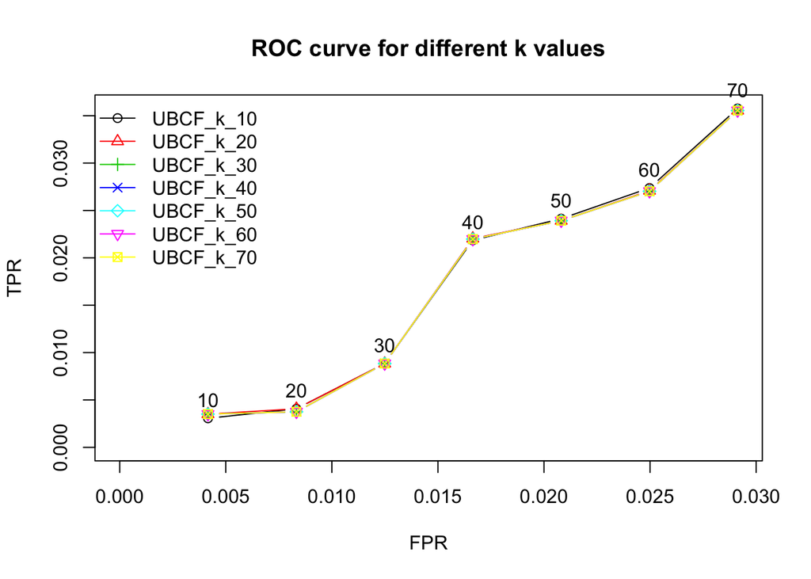

```r
plot(list_results, annotate = 1, legend ="topleft")
title("ROC curve for different k values")
```

This evaluation took about 44 seconds for each iteration.

Now a similarity matrix is calculated containing all user-to-user similarities using Pearson and Cosine similary measures.

```r
model_to_evaluate <- "UBCF"
model_parameters <- list(normalize = "Z-Score", method="Cosine", nn=70)

model_cosine <- Recommender(getData(eval_sets,"train"),model_to_evaluate,param=model_parameters)

prediction_cosine <- predict(model_cosine,getData(eval_sets,"known"),type="ratings")

rmse_cosine <- calcPredictionAccuracy(prediction_cosine, getData(eval_sets, "unknown"))[1]
rmse_cosine
```

```
##     RMSE
## 0.413039
```

```r
#0.3850089
```

Now preparation for the prediction and get prediction for the top 5 users.

```r
Titlelookup  <- subset(dfbooks,select = c(1,2))
colnames(Titlelookup) <- c("ISBN","title")
Titlelookup <- Titlelookup[duplicated(Titlelookup)==FALSE,]

getTitle <- function(ISBN1) {
  title <- subset(Titlelookup, ISBN == ISBN1)$title
}
## Create databases here

pred2 <- predict(model_cosine,getData(eval_sets, "unknown"),n=5)
# view the recommendations for top 5 users
#as(pred2,"list")[1:5]
#pred2Copy <- pred2
```

```r
#define a list with the recommendations for each user
recc_matrix <- lapply(pred2@items, function(x){
  colnames(rdf)[x]
})

# Let's take a look at the recommendations for the first 3 users:
recc_matrix[1:3]
```

```
## $`114`
## [1] "0671004573" "0385492081" "0440419468" "0679772669" "3442441641"
##
## $`387`
## [1] "014131088X" "0380788691" "0380820900" "0553285343" "1573229865"
##
## $`444`
## [1] "0553585118" "0553582747" "0064407055" "067164257X" "0684831546"
```

Now, to get recommendation from the UBCF method to display on the Shiny UI.

The prediction by userID could not be done due to an error that could not be resolved due to time restrictions.

Error: If newdata is a user id then data needes to be the training dataset.

#### b) Distance methods:

This method gives measurement of the similarity between users/items based on the distance between them.Popular models are pearson, jaccard and cosine.

```r
model_to_evaluate <- "UBCF"
kval <- 70
valList <- c(0, 20,30,40,50,60,70)

model_parameters1 <- list(normalize = "Z-score",method="Cosine",nn=kval)
model_parameters2 <- list(normalize = "Z-score",method="Pearson",nn=kval)
model_parameters3 <- list(normalize = "Z-score",method="jaccard",nn=kval)


distItem <- list(
   "Cosine" = list(name=model_to_evaluate, param=model_parameters1),
   "Pearson" = list(name=model_to_evaluate, param=model_parameters2),
   "Jaccard" = list(name=model_to_evaluate, param=model_parameters3)

)

dist_resultsUBCF <- evaluate(eval_sets, distItem, n=valList)
```

```
## UBCF run fold/sample [model time/prediction time]
##   1  [1.587sec/45.511sec]
## UBCF run fold/sample [model time/prediction time]
##   1  [1.556sec/24.245sec]
## UBCF run fold/sample [model time/prediction time]
##   1  [1.466sec/32.71sec]
```

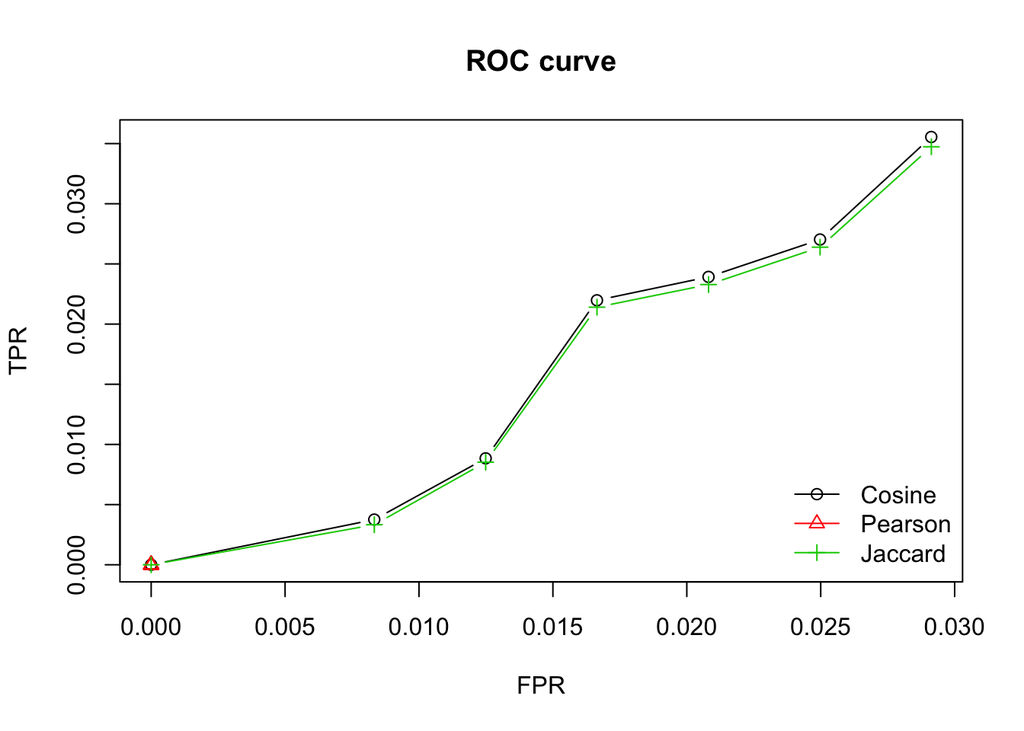

```r
#avg(dist_resultsUBCF)

plot(x=dist_resultsUBCF, y ="ROC")
title("ROC curve")
```

#### c) Normalization method:

Data needs to be normalized before applying any algorithm. (normalization is done here by taking user’s averages - which is mean ratings of every user subtracted from known ratings)

Use normalization method for Z score using center and z-score parameters to feed the recommenderlab.

```r
alg_dist <- list(
   "center" = list(name="UBCF", param=list(normalize = "center",method="Cosine",nn=70)),
   "Zscore" = list(name="UBCF", param=list(normalize = "Z-score",method="Cosine",nn=70))
)

dist_resultsUBCF <- evaluate(eval_sets, alg_dist, n=c(1, 5, 10, 15, 20, 25))
```

```
## UBCF run fold/sample [model time/prediction time]
##   1  [1.018sec/49.072sec]
## UBCF run fold/sample [model time/prediction time]
##   1  [1.65sec/47.087sec]
```

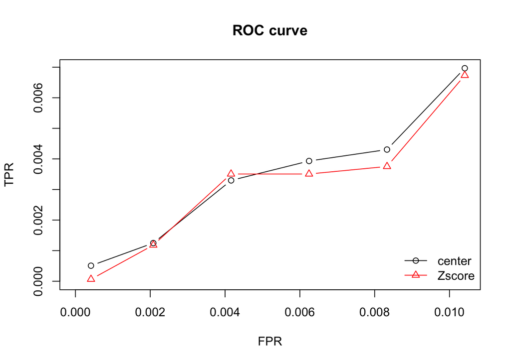

```r
#plot ROC
plot(x = dist_resultsUBCF, y = "ROC")
title("ROC curve")
```

The Center option did better than ZScore.

### III. SVD Recommender

Singular Value Decomposition(SVD), a data analysis will be used to create the SVD recommender. SVD was used by BellKor team in their recommender project that won the Netflix Prize in 2009. SVD is a matrix factorization technique used to reduce the number of features of a given dataset by reducing dimensions and the matrix factorization here is performed on a user-item ratings matrix.

```r
booksummary <- dfbookratingsvalid %>%
  group_by(isbn) %>%
  summarise(
    avg_review = mean(rating))


# Computing the SVD
decomp = irlba(ratingdcast, nu = 3, nv = 3)
```

The matrix factorization technique called Singular value decomposition (SVD) is used to reduce dimensionality, so neighborhood formation happens in a reduced user space. SVD helps the model to find the low rank dataset matrix. However, SVD is computationally expensive. So the irlba, a package from R will be used to perform the *singular value decomposition*. The irlba function computes only the number of singular values corresponding to the maximum of the desired singular vectors, max(nu, nv). For example, if 5 singular vectors are desired (nu=nv=5), then only the five corresponding singular values are computed. In contrast, SVD without irlba function always returns the total set of singular values for the matrix, regardless of how many singular vectors are specified.

The *irlba* package provides a fast way to compute partial singular value decompositions (SVD) of large sparse or dense matrices. The paramters to irlba are: nv = number of right singular vectors to estimate nu = number of left singular vectors to estimate

```r
# Generating the prediction matrix
predBook = booksummary$avg_review + (decomp$u * sqrt(decomp$d)) %*% (sqrt(decomp$d) * t(decomp$v))

RMSE <- function(predictionMatrix, actualMatrix){
  sqrt(mean((predictionMatrix - actualMatrix)^2, na.rm=T))
}


# actualMatrix
NADF <- ratingdcast
is.na(NADF) <- NADF == 0
RMSE(predBook, NADF)
```

```
## [1] 5.45191
```

```r
#5.45191
```

### IV. Item-Based Recommender Filtering

#### a) Optimizing a numeric parameter ( Neighborhood size):

Recommendation models contain a numeric parameter that takes account of the k-closest users/items. k can be optimized, by testing different values of a numeric parameter. So, we can get the value we want to proceed testing with. Default k value is 30. We can explore ranges from 10 and 70. Building and evaluating the models:

Now a similarity matrix is calculated containing all user-to-user similarities using Cosine similary measures.

```r
model_to_evaluate <- "IBCF"
model_parameters <- list(normalize = "Z-Score", method="Cosine", k=70)

model_cosineIBCF <- Recommender(getData(eval_sets,"train"),model_to_evaluate,param=model_parameters)

prediction_cosineIBCF <- predict(model_cosineIBCF,getData(eval_sets,"known"),type="ratings")

rmse_cosineIBCF <- calcPredictionAccuracy(prediction_cosineIBCF, getData(eval_sets, "unknown"))[1]
rmse_cosineIBCF
```

```
##     RMSE
## 5.450936
```

```r
#0.3850089
```

#### b) Distance methods:

This method gives measurement of the similarity between users/items based on the distance between them.Popular models are pearson, jaccard and cosine.

```r
model_to_evaluate <- "IBCF"
kval <- 70
valList <- c(0, 20,30,40,50,60,70)

model_parameters1 <- list(normalize = "Z-score",method="Cosine",k=kval)
model_parameters2 <- list(normalize = "Z-score",method="Pearson",k=kval)
model_parameters3 <- list(normalize = "Z-score",method="jaccard",k=kval)


distItem <- list(
   "Cosine" = list(name=model_to_evaluate, param=model_parameters1),
   "Pearson" = list(name=model_to_evaluate, param=model_parameters2),
   "Jaccard" = list(name=model_to_evaluate, param=model_parameters3)

)

dist_resultsIBCF <- evaluate(eval_sets, distItem, n=valList)
```

```
## IBCF run fold/sample [model time/prediction time]
##   1  [199.112sec/0.274sec]
## IBCF run fold/sample [model time/prediction time]
##   1  [117.435sec/0.265sec]
## IBCF run fold/sample [model time/prediction time]
##   1  [142.029sec/0.351sec]
```

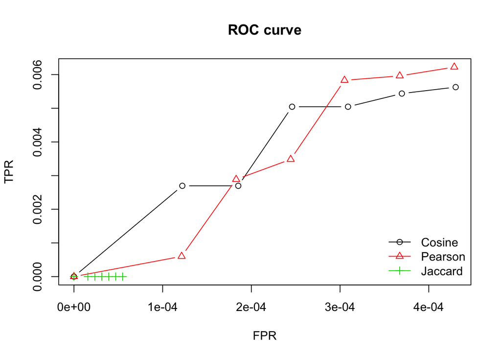

```r
#avg(dist_resultsIBCF)

plot(x=dist_resultsIBCF, y ="ROC")
title("ROC curve")
```

Now prediction using IBCF.